# Testing Hypotheses about Means

b06208001 龔泓愷

2018年11月25日

## Q1324

**Step1**  
H0：mu = 72，Penn State men have a mean of 72.  
Ha：mu != 72，Penn State men do not have a mean of 72.

**Step2**  
Since it assume the sample is representative of all Penn State men,  
and the sample size(n = 57) is **large enough**, the conditions to carry out the one-sample t-test for mean are met.

```r
n = 57; mu = 72; x_bar = 70.42; sd = 9.95
s.e. = sd/sqrt(n);s.e.
```

```
## [1] 1.31791
```

```r
df = n - 1;df
```

```
## [1] 56
```

```r
t_value = (x_bar - mu)/s.e.;t_value
```

```
## [1] -1.198868
```

**Step3**

```r
p_value = pt(t_value, df = df)*2;p_value#Two-tailed
```

```
## [1] 0.2356278
```

**Step4**  
I’ll assume that the significance level here is 0.05(alpha = 0.05).  
Since the p-value is much greater than alpha, we cannot reject the null hypothesis in favor of the alternative hypothesis.

**Step5**  
Although the sample data is in the right direction of the mean,  
the sample didn’t provide enough sample to reject the null hypothesis.  
Since I cannot reject the null hypothesis,  
I cannot conclude that the Penn State men do not have a mean of 72  
because I cannot reject the possibility that Penn State men have a mean of 72.

**Step1**  
H0：mu = 72，Penn State women have a mean of 72.  
Ha：mu != 72，Penn State women do not have a mean of 72.

**Step2**  
Since it assume the sample is representative of all Penn State women,  
and the sample size(n = 35) is **large enough**, the conditions to carry out the one-sample t-test for mean are met.

```r
n = 35; mu = 72; x_bar = 76.9; sd = 11.6
s.e. = sd/sqrt(n);s.e.
```

```
## [1] 1.960758
```

```r
df = n - 1;df
```

```
## [1] 34
```

```r
t_value = (x_bar - mu)/s.e.;t_value
```

```
## [1] 2.499034
```

**Step3**

```r
p_value = pt(t_value, df = df, lower.tail = F)*2;p_value#Two-tailed
```

```
## [1] 0.01744642
```

**Step4**  
I’ll assume that the significance level here is 0.05(alpha = 0.05).  
Since the p-value is much smaller than alpha, we can reject the null hypothesis in favor of the alternative hypothesis.

**Step5**  
The sample here is statistically significant.  
The sample here provides sufficient evidence to reject the null hypothesis.  
Hence, I can conclude that Penn State women have a mean which is different from 72.

3. From part(a) and part(b), we can conclude that the mean pulse rate is different from 72 for Penn State women.  
   However, for Penn State men, we cannot make that conclusion since we cannot reject the possibility that the mean rate is 72.

## Q1338

1. **Step1**  
   H0：Dominant hand - Non-dominant hand = 0  
   H1：Dominant hand - Non-dominant hand > 0

```r
diff = c(4,4,5,1,-2,0,2,4,-3,0,0,0,-2,2,1)#Dominant hand - Non-dominant hand
```

2. **Step2**  
   The sample size is not large enough, so we need to check its skewness and outliers.  
   Here is the boxplot for the sample data:

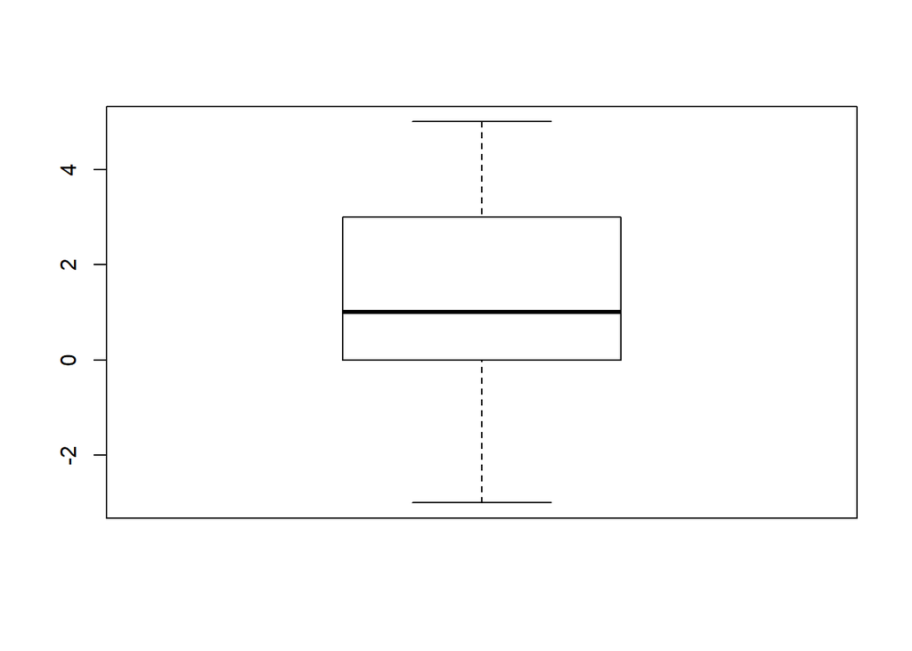

```r
boxplot(diff)
```

There isn’t much noticeable skewness or any outliers.  
Hence, the conditions to carry out the one-sample t-test for mean are met.

```r
n = 15;dbar = mean(diff);sd = sd(diff)
s.e. = sd/sqrt(n);s.e.
```

```
## [1] 0.6284271
```

```r
df = n - 1;df
```

```
## [1] 14
```

```r
t_value = (dbar - 0)/s.e.;t_value
```

```
## [1] 1.697359
```

**Step3**

```r
p_value = pt(t_value, df = df, lower.tail = F);p_value
```

```
## [1] 0.05586857
```

**Step4c**  
Since the p-value is larger than the significance level(alpha = 0.05),  
We cannot reject the null hypothesis in foavor of the alternative hypothesis.

**Step5c**  
Although the sample data is in the right direction of the mean,  
the sample didn’t provide enough sample to reject the null hypothesis.  
Since I cannot reject the null hypothesis,  
I cannot conclude that the dexerity of their dominant hands is better than the one of their non-dominant hands  
because I cannot reject the possibility that the dexerity of their dominant hands and the one of their non-dominant hands are the same.

**Step4d**  
Since the p-value is smaller than the significance level(alpha = 0.1),  
We can reject the null hypothesis in foavor of the alternative hypothesis.

**Step5d**  
The sample here is statistically significant.  
The sample here provides sufficient evidence to reject the null hypothesis.  
Hence, I can conclude that the dexerity of their dominant hands is better than the one of their non-dominant hands.

5. Using the data sample here, we can approximately conclude that dexerity of their dominant hands is better than the one of their non-dominant hands.  
   However, by making this conclusion, there is a risk of 5.59%(p-value) that we might be wrong in our conclusion.

## Q1358

**Step1**  
H0：the mean number of hours of sleep for the two populations of students are equal.  
Ha：the mean number of hours of sleep for the two populations of students are not equal.

*UNPOOLED*

```r
n1 = 25; xbar1 = 7.66; sd1 = 1.34
n2 = 148; xbar2 = 6.81; sd2 = 1.73
s.e. = sqrt(sd1^2/n1 + sd2^2/n2);s.e.
```

```
## [1] 0.3033913
```

```r
df = 38#題目給的
t_value = ((xbar1 - xbar2) - 0)/s.e.;t_value
```

```
## [1] 2.801662
```

**Step3a**

```r
p_value = pt(t_value, df = df, lower.tail = F)*2;p_value#Two-sided
```

```
## [1] 0.007954814
```

**Step4a**  
I’ll assume that the significance level here is 0.05(alpha = 0.05).  
Since the p-value is much smaller than alpha, we can reject the null hypothesis in favor of the alternative hypothesis.

**Step5a**  
The sample here is statistically significant.  
The sample here provides sufficient evidence to reject the null hypothesis.  
Hence, I can conclude that the mean number of hours of sleep for the two populations of students are not equal.

**Step2c**

*POOLED*

```r
sp = sqrt(((n1-1)*sd1^2 + (n2-1)*sd2^2)/(n1+n2-2));sp#Pooled sd
```

```
## [1] 1.680731
```

```r
s.e.pooled = sp*sqrt(1/n1 + 1/n2);s.e.pooled#Pooled se
```

```
## [1] 0.3634298
```

```r
df = n1 + n2 - 2;df
```

```
## [1] 171
```

```r
t_value = ((xbar1 - xbar2) - 0)/s.e.pooled;t_value
```

```
## [1] 2.338829
```

**Step3c**

```r
p_value = pt(t_value, df = df, lower.tail = F)*2;p_value#Two-sided
```

```
## [1] 0.02050042
```

**Step4c**  
I’ll assume that the significance level here is 0.05(alpha = 0.05).  
Since the p-value is much smaller than alpha, we can reject the null hypothesis in favor of the alternative hypothesis.

**Step5c**  
The sample here is statistically significant.  
The sample here provides sufficient evidence to reject the null hypothesis.  
Hence, I can conclude that the mean number of hours of sleep for the two populations of students are not equal.

Evcen though we got the same conclusion by using both unpooled and pooled procedure,  
it is better to use the unpooled one in this case  
because **neither the sample sizes nor the standard deviations are similar**.

## Q1364

H0：mu = 25；alpha = 0.05  
a. Two-sided test：Yes, H0 can be rejected since **the confidence interval does not cover the null value**.  
b. One-sided test：No, H0 cannot be rejected since **the entire confidence interval do not fall above the null value**.  
c. One-sided test：No, H0 cannot be rejected since **the entire confidence interval do not fall below the null value**.

## Q1376

1. Max was interested in the proportion of people who were born in October(p).  
   There is only **one** random sample(his birthday calender), and it’s a **categorical** variable(month).  
   Consequently, the parameter of interest is *p*, the population proportion.  
   A hypothesis test is enough here. H0：p = 1/12；Ha：p > 1/12
2. The researchers un the study might interested in the mean difference between cholesterol levles for patients 2 & 4 days after they’ve got a heart attack(mud).  
   There is only **one** random sample(heart attack patients) of which each patient was **measured twice in the same measurements**(day 2 & 4).  
   Consequently, the parameter of interest is *mud*, the population mean of paired differences.  
   A confidence level is enough here since we expect that day2 is higher than day4.

## Q1378

1. The effect size for (a) is 0.2702 which is considered to be a **Small** effect.

```r
n = 30
t = 1.48
d_hat = t/sqrt(n);d_hat
```

```
## [1] 0.2702098
```

2. The effect size for (b) is -0.4943 which is considered to be a **Medium** effect.

```r
n1 = 40; n2 = 50
t = -2.33
d_hat = t*sqrt(1/n1 + 1/n2);d_hat
```

```
## [1] -0.4942676
```